# rpresentation

"Eric Taylor"  
"December 11, 2016"

### Concept

Purchasing an engagement ring is a stressful experience. Individuals are confronted with conflicting issues:

- Are they paying a fair price? (looking to minimize cost)
- Are they buying something with enough “bling” factor? (need to spend a lot of money)

These 2 things pull in opposite directions. This app is trying to reduce stress by providing answers to both of these questions.

### How does it work?

A simple linear model was fit on ggplot2's diamonds dataset, including interaction terms. It focuses on the 4 Cs of diamonds:

1. Carats
2. Cut
3. Color
4. Clarity

Users then simply enter in the 4 Cs of the diamond they are considering, and report is generated advising them on their purchase. An estimated price tells them if the store is **charging too much**. The percentile rank of the price confirms if **their budget is too conservative**.

### Model Code

The server calculation can be summarized as follows:

```r
diamonds <- diamonds %>% select(price, carat, cut, color, clarity)
model <- lm(price ~ .*., data=diamonds)
result <- predict(model, input)

output$hist =
    renderPlot({ggplot(diamonds, aes(price))
    + geom_histogram()
    + geom_vline(aes(xintercept=result))
})
output$value = renderText({
    round(result, 2))
})
output$bling = renderText({
    round(100*sum(diamonds$price<result)
    / nrow(diamonds), 2))
})
```

### Is it Accurate?

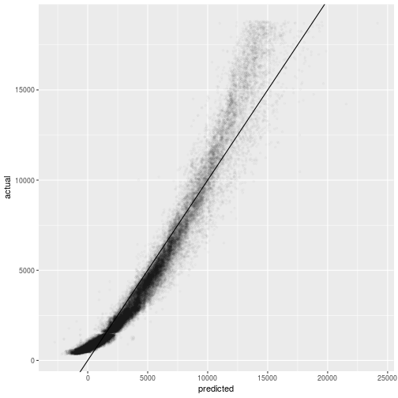

There is room for improvement, with some clear non-linear effects. This model is just a proof of concept, it can be further refined and enhanced.